# Prediction on Trips 2015

Nikola Baci

6/21/2021

# Prediction of the trips on theyear 2015

## Engineer the features and clean the data

```r
# load the big dataframe, select only the yeah-month-day column,
# count the number of trips per each day, filter out "2016-01-01"
trips_per_day_2015 <- select(trips, ymd) %>%
  group_by(ymd) %>%
  summarize(num_trips = n()) %>%
  filter(ymd < "2016-01-01")

# add the weather data
weather <- mutate(weather,
                  ymd = as.Date(parse_datetime(date)))

# the weather data was supposed to have a Date-type column, but it did not,
# so I added one
trips_per_day_2015 <- inner_join(trips_per_day_2015, weather, by="ymd")

# add the day of the week with lubridate (it encodes the days 1 to 7)
trips_per_day_2015 <- mutate(trips_per_day_2015, day_of_week = wday(ymd))

# decode the days
trips_per_day_2015 <- mutate(trips_per_day_2015,
                        day_of_week=factor(day_of_week, levels=c(1,2,3,4,5,6,7),
                                           labels=c("Sunday", "Monday","Tuesday","Wednesday", "Thursday", "Friday", "Saturday")))

# create a boolean column work_day (0 = weekend, 1 = weekday)
trips_per_day_2015 <- mutate(trips_per_day_2015,
                        work_day = factor(day_of_week,
                                           levels=c("Sunday", "Monday","Tuesday","Wednesday", "Thursday", "Friday", "Saturday"),
                                           labels=c(0,1,1,1,1,1,0)))

# create a boolean column did_not_snow (0 = snowed, 1 = did not snow)
trips_per_day_2015 <- mutate(trips_per_day_2015, did_not_snow = 1 - as.integer(trips_per_day_2015$snwd > 5))

# create a boolean column did_not_rain (0 = rained, 1 = did not rain)
trips_per_day_2015 <- mutate(trips_per_day_2015, did_not_rain = 1 -as.integer(trips_per_day_2015$prcp > 1))

# the model was trained with tmax being 1/10 of the original tmax, so lets change it to that
trips_per_day_2015 <- trips_per_day_2015 %>%
  mutate(tmax = tmax / 10)
```

## Let’s test the the model on this data set

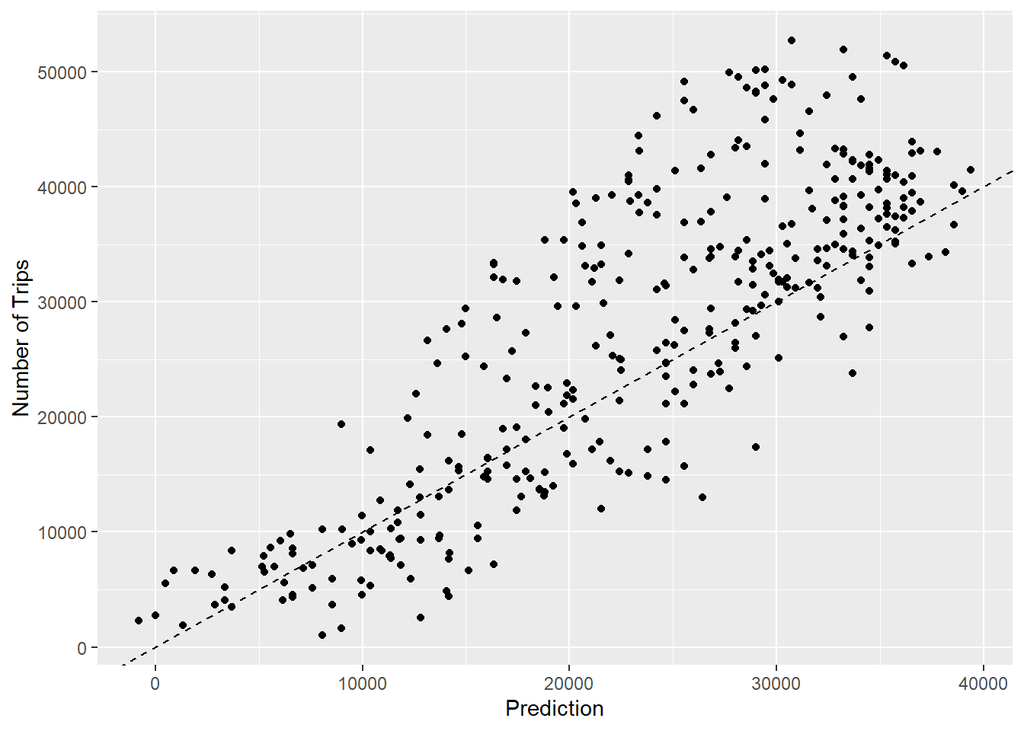

```r
# make predictions
trips_per_day_2015 <-  trips_per_day_2015 %>%
  add_predictions(model_6)

# calculate the Root Mean Square Error
error_2015 <- sqrt(mean((predict(model_6, trips_per_day_2015) - trips_per_day_2015$num_trips)^2))

# plot the results
trips_per_day_2015 %>%
  ggplot() +
  geom_point(aes(x = pred, y = num_trips)) +
  geom_abline(linetype = "dashed") +
  xlab("Prediction") +
  ylab("Number of Trips")
```

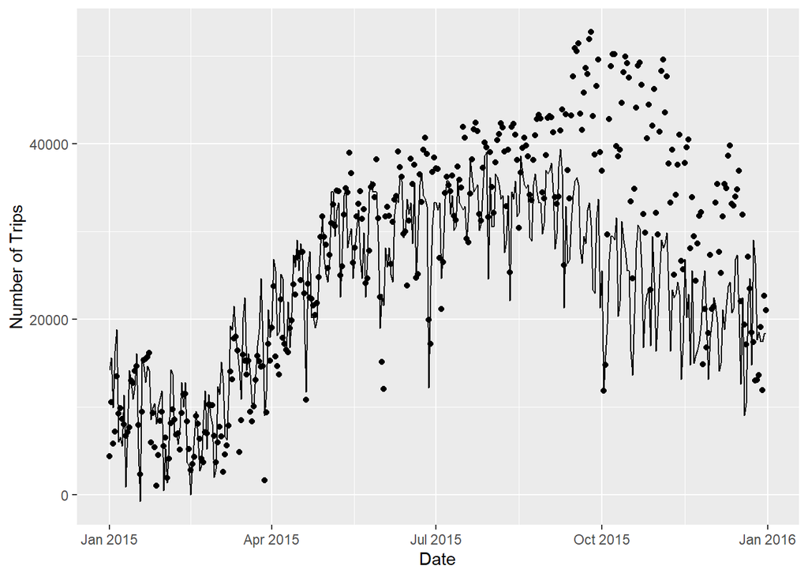

```r
trips_per_day_2015 %>%
  ggplot() +
  geom_line(aes(x = ymd, y = pred)) +
  geom_point(aes(x = ymd, y = num_trips)) +
  xlab("Date") +
  ylab("Number of Trips")
```

## Conlcusions

In my training notebook “predict_citibike.Rmd”, I expressed my optimism that the model will fit the same or better to the new dataset compared to my very small test set (37 observations). It turns out that the model is doing worst than I predicted.

Reflecting on why the model did more poorly that I thought, could be that my test evaluation was a not a big enough dataset to give me good insights on the model. Hence, by having more observations, the residuals help increase the error.

Another problem is the model itself, as we can see from the first graph above, the model is not fitted properly to the data. By eye I could suggest that a smaller intercept and a bigger slope could help in this case. I do not exclude the idea that this could also be due to change or specific to this dataset, meaning that in another dataset the model could perform much better.